# 5206.hw7.cm3700

Chi.Ma,cm3700

11/27/2017

```r
setwd("~/Desktop/5206/HW")
df<-read.csv("moretti.csv")
```

# Part1

```r
poisLoglik<-function(data,lambda){
  return(sum(dpois(x=data,lambda=lambda,log = TRUE)))
}
poisLoglik(c(1,0,0,1,1),1)
```

```
## [1] -5
```

# part2

Write a function count new genres which takes in a year, and returns the number of new genres which appeared in that year: 0 if there were no new genres that year, 1 if there was one, 3 if there were three, etc. What should the values be for 1803 and 1850?

```r
count_new_genres<-function(year){
  return(sum(df$Begin==year))
}
count_new_genres(1803)
```

```
## [1] 0
```

```r
count_new_genres(1850)
```

```
## [1] 3
```

# part3

Create a vector, new genres, which counts the number of new genres which appeared in each year of the data, from 1740 to 1900. What positions in the vector correspond to the years 1803 and 1850? What should those values be? Is that what your vector new genres has for those years?

```r
years<-seq(1740,1900)
new_genres<-rep(NA,length(years))

for(i in 1:length(years)){
  new_genres[i]<-count_new_genres(years[i])
}

which(years==1803)
```

```
## [1] 64
```

```r
which(years==1850)
```

```
## [1] 111
```

```r
new_genres[years==1805]
```

```
## [1] 0
```

```r
new_genres[years==1850]
```

```
## [1] 3
```

```r
#The positions for year 1803 and 1850 are 64 and 111, and the values are 0 and 3 respectively.
```

# Part4

Plot poisLoglik as a function of λ on the new_genres data. (If the maximum is not at λ = 0.273, you’re doing something wrong.)

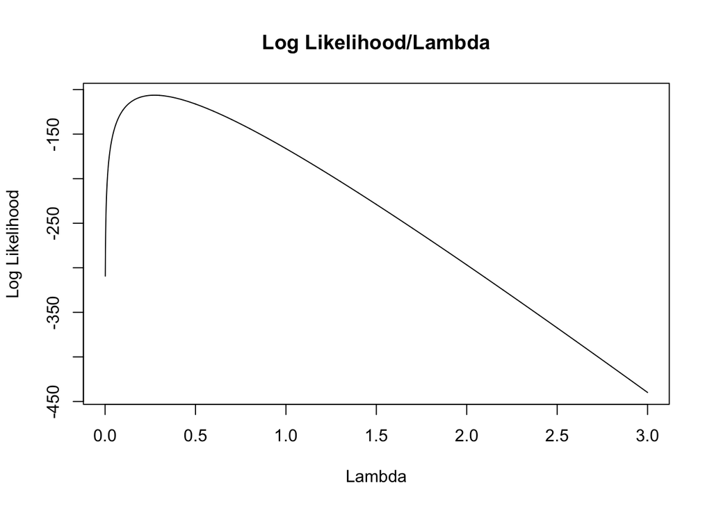

```r
lambda<-seq(0,3,by=0.001)
likelihood<-c()
for(i in 1:length(lambda)){
  likelihood<-c(likelihood,poisLoglik(new_genres,lambda[i]))
}
plot(lambda,likelihood,type = "l",,xlab = "Lambda",ylab = "Log Likelihood",main = "Log Likelihood/Lambda")
```

```r
lambda[which.max(likelihood)]
```

```
## [1] 0.273
```